# Multistate exercise solutions

Author

Nicole De La Mata

## Data description

The dataset comprises of a random sample of real world data of people entering the kidney waitlist to receive a deceased donor transplant. The data has been perturbed and includes the below state space, which ignores deaths. The dataset has not been prepared via msprep, and has been manually prepared to reflect a similar output that msprep would produce (if it allowed for circular transitions).

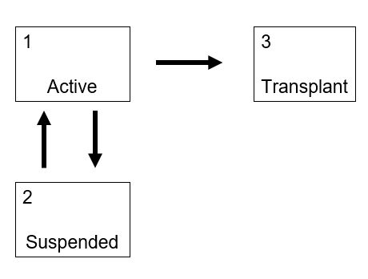

The variables provided include:

id: Unique patient identifier

Tstart: Time point from

Tstop: Time point to

Time: Time of the transition

from: State from (1==Active, 2==Suspended, 3==Transplant)

to: State to (1==Active, 2==Suspended, 3==Transplant)

trans: Transition type (1==from active to suspended, 2==from suspended to active, 3==from active to transplant)

status: Event indicator (1==event occurred, 0==censored)

hospunit: Hospital unit providing care (factor variable)

age: age in years at dialysis start

malesex: indicator for male sex (1==male, 0==female)

late: referral for kidney failure was late (1==late referral, 0==Not late referral)

Consider also creating a time-varying covariate for number of suspensions over time.

## Load data

```r
#-----read data
#load libraries
library(dplyr)
library(tidyr)
library(ggplot2)
library(survival)
library(mstate)
library(flexsurv)
library(mvna)
library(readr)


wt_trans <- read_csv("https://raw.githubusercontent.com/NicoleDeLaMata/AdvancedSurvival/refs/heads/Data/waitlist_trans.csv")

#Create as factor
wt_trans$hospunit <- factor(wt_trans$hospunit)
```

## Fit transition-specific Cox model

```r
#Fit transition: active to suspended
cox_active_sus <- coxph(Surv(Tstart, Tstop, status) ~ hospunit + age + malesex + late, data=wt_trans, subset=(trans==1), id=id)
summary(cox_active_sus)
```

```
Call:
coxph(formula = Surv(Tstart, Tstop, status) ~ hospunit + age +
    malesex + late, data = wt_trans, subset = (trans == 1), id = id)

  n= 1267, number of events= 749

               coef exp(coef)  se(coef) robust se      z Pr(>|z|)
hospunit2 -0.514289  0.597926  0.104738  0.111697 -4.604 4.14e-06 ***
hospunit3  0.077372  1.080444  0.112682  0.143588  0.539    0.590
age        0.004599  1.004610  0.002856  0.003534  1.301    0.193
malesex    0.089644  1.093785  0.075190  0.084375  1.062    0.288
late       0.059506  1.061312  0.106988  0.122899  0.484    0.628
---
Signif. codes:  0 '***' 0.001 '**' 0.01 '*' 0.05 '.' 0.1 ' ' 1

          exp(coef) exp(-coef) lower .95 upper .95
hospunit2    0.5979     1.6724    0.4804    0.7443
hospunit3    1.0804     0.9255    0.8154    1.4316
age          1.0046     0.9954    0.9977    1.0116
malesex      1.0938     0.9143    0.9271    1.2905
late         1.0613     0.9422    0.8341    1.3504

Concordance= 0.555  (se = 0.013 )
Likelihood ratio test= 33.76  on 5 df,   p=3e-06
Wald test            = 25.77  on 5 df,   p=1e-04
Score (logrank) test = 31.21  on 5 df,   p=9e-06,   Robust = 24.53  p=2e-04

  (Note: the likelihood ratio and score tests assume independence of
     observations within a cluster, the Wald and robust score tests do not).
```

```r
#Fit transition: suspended to active
cox_sus_active <- coxph(Surv(Tstart, Tstop, status) ~ hospunit + age + malesex + late, data=wt_trans, subset=(trans==2), id=id)
summary(cox_sus_active)
```

```
Call:
coxph(formula = Surv(Tstart, Tstop, status) ~ hospunit + age +
    malesex + late, data = wt_trans, subset = (trans == 2), id = id)

  n= 896, number of events= 446

               coef exp(coef)  se(coef) robust se      z Pr(>|z|)
hospunit2 -0.352707  0.702783  0.149487  0.165354 -2.133  0.03292 *
hospunit3  0.640923  1.898232  0.137971  0.224409  2.856  0.00429 **
age       -0.019059  0.981122  0.003180  0.004440 -4.292 1.77e-05 ***
malesex   -0.169820  0.843817  0.097665  0.135313 -1.255  0.20947
late      -0.009516  0.990530  0.129591  0.170978 -0.056  0.95562
---
Signif. codes:  0 '***' 0.001 '**' 0.01 '*' 0.05 '.' 0.1 ' ' 1

          exp(coef) exp(-coef) lower .95 upper .95
hospunit2    0.7028     1.4229    0.5082    0.9718
hospunit3    1.8982     0.5268    1.2227    2.9469
age          0.9811     1.0192    0.9726    0.9897
malesex      0.8438     1.1851    0.6472    1.1001
late         0.9905     1.0096    0.7085    1.3849

Concordance= 0.61  (se = 0.019 )
Likelihood ratio test= 66.63  on 5 df,   p=5e-13
Wald test            = 41.12  on 5 df,   p=9e-08
Score (logrank) test = 72.98  on 5 df,   p=2e-14,   Robust = 28.45  p=3e-05

  (Note: the likelihood ratio and score tests assume independence of
     observations within a cluster, the Wald and robust score tests do not).
```

```r
#Fit transition: active to transplant
cox_active_tx <- coxph(Surv(Tstart, Tstop, status) ~ hospunit + age + malesex + late, data=wt_trans, subset=(trans==3), id=id)
summary(cox_active_tx)
```

```
Call:
coxph(formula = Surv(Tstart, Tstop, status) ~ hospunit + age +
    malesex + late, data = wt_trans, subset = (trans == 3), id = id)

  n= 1267, number of events= 419

               coef exp(coef)  se(coef)      z Pr(>|z|)
hospunit2  0.166386  1.181029  0.119769  1.389  0.16476
hospunit3  0.588997  1.802180  0.140531  4.191 2.77e-05 ***
age       -0.014216  0.985884  0.003620 -3.927 8.61e-05 ***
malesex    0.317431  1.373594  0.103009  3.082  0.00206 **
late       0.009416  1.009461  0.140074  0.067  0.94640
---
Signif. codes:  0 '***' 0.001 '**' 0.01 '*' 0.05 '.' 0.1 ' ' 1

          exp(coef) exp(-coef) lower .95 upper .95
hospunit2    1.1810     0.8467    0.9339    1.4935
hospunit3    1.8022     0.5549    1.3683    2.3737
age          0.9859     1.0143    0.9789    0.9929
malesex      1.3736     0.7280    1.1225    1.6809
late         1.0095     0.9906    0.7671    1.3284

Concordance= 0.587  (se = 0.017 )
Likelihood ratio test= 39.37  on 5 df,   p=2e-07
Wald test            = 41.2  on 5 df,   p=9e-08
Score (logrank) test = 41.72  on 5 df,   p=7e-08
```

Alternatively, we can fit using the `strata()` option and this should yield the same results as the transition-specific models.

```r
#Expand covariates to fit transition-specific covariates
wt_trans_exp <- wt_trans %>%
  mutate(hospunit.1 = ifelse(trans==1, hospunit, 1),
         hospunit.2 = ifelse(trans==2, hospunit, 1),
         hospunit.3 = ifelse(trans==3, hospunit, 1),
         age.1 = ifelse(trans==1, age, 0),
         age.2 = ifelse(trans==2, age, 0),
         age.3 = ifelse(trans==3, age, 0),
         malesex.1 = ifelse(trans==1, malesex, 0),
         malesex.2 = ifelse(trans==2, malesex, 0),
         malesex.3 = ifelse(trans==3, malesex, 0),
         late.1 = ifelse(trans==1, late, 0),
         late.2 = ifelse(trans==2, late, 0),
         late.3 = ifelse(trans==3, late, 0))

#Factor variables
wt_trans_exp$hospunit.1 <- factor(wt_trans_exp$hospunit.1, levels=c(1,2,3))
wt_trans_exp$hospunit.2 <- factor(wt_trans_exp$hospunit.2)
wt_trans_exp$hospunit.3 <- factor(wt_trans_exp$hospunit.3)

#Fit cox model with transition specific covariates
cox.strata <- coxph(Surv(Tstart, Tstop, status) ~ hospunit.1 + hospunit.2 + hospunit.3 + age.1 + age.2 + age.3 + malesex.1 + malesex.2 + malesex.3 + late.1 + late.2 + late.3 + strata(trans),
data=wt_trans_exp, id=id)
summary(cox.strata)
```

```
Call:
coxph(formula = Surv(Tstart, Tstop, status) ~ hospunit.1 + hospunit.2 +
    hospunit.3 + age.1 + age.2 + age.3 + malesex.1 + malesex.2 +
    malesex.3 + late.1 + late.2 + late.3 + strata(trans), data = wt_trans_exp,
    id = id)

  n= 3430, number of events= 1614

                 coef exp(coef)  se(coef) robust se      z Pr(>|z|)
hospunit.12 -0.514289  0.597926  0.104738  0.111697 -4.604 4.14e-06 ***
hospunit.13  0.077372  1.080444  0.112682  0.143588  0.539 0.589992
hospunit.22 -0.352707  0.702783  0.149487  0.165354 -2.133 0.032921 *
hospunit.23  0.640923  1.898232  0.137971  0.224409  2.856 0.004289 **
hospunit.32  0.166386  1.181029  0.119769  0.119962  1.387 0.165445
hospunit.33  0.588997  1.802180  0.140531  0.133845  4.401 1.08e-05 ***
age.1        0.004599  1.004610  0.002856  0.003534  1.301 0.193167
age.2       -0.019059  0.981122  0.003180  0.004440 -4.292 1.77e-05 ***
age.3       -0.014216  0.985884  0.003620  0.003753 -3.788 0.000152 ***
malesex.1    0.089644  1.093785  0.075190  0.084375  1.062 0.288031
malesex.2   -0.169820  0.843817  0.097665  0.135313 -1.255 0.209472
malesex.3    0.317431  1.373594  0.103009  0.106565  2.979 0.002894 **
late.1       0.059506  1.061312  0.106988  0.122899  0.484 0.628255
late.2      -0.009516  0.990530  0.129591  0.170978 -0.056 0.955618
late.3       0.009416  1.009461  0.140074  0.145594  0.065 0.948432
---
Signif. codes:  0 '***' 0.001 '**' 0.01 '*' 0.05 '.' 0.1 ' ' 1

            exp(coef) exp(-coef) lower .95 upper .95
hospunit.12    0.5979     1.6724    0.4804    0.7443
hospunit.13    1.0804     0.9255    0.8154    1.4316
hospunit.22    0.7028     1.4229    0.5082    0.9718
hospunit.23    1.8982     0.5268    1.2227    2.9469
hospunit.32    1.1810     0.8467    0.9336    1.4941
hospunit.33    1.8022     0.5549    1.3863    2.3428
age.1          1.0046     0.9954    0.9977    1.0116
age.2          0.9811     1.0192    0.9726    0.9897
age.3          0.9859     1.0143    0.9787    0.9932
malesex.1      1.0938     0.9143    0.9271    1.2905
malesex.2      0.8438     1.1851    0.6472    1.1001
malesex.3      1.3736     0.7280    1.1147    1.6926
late.1         1.0613     0.9422    0.8341    1.3504
late.2         0.9905     1.0096    0.7085    1.3849
late.3         1.0095     0.9906    0.7589    1.3428

Concordance= 0.572  (se = 0.01 )
Likelihood ratio test= 139.8  on 15 df,   p=<2e-16
Wald test            = 101  on 15 df,   p=8e-15
Score (logrank) test = 145.9  on 15 df,   p=<2e-16,   Robust = 88.12  p=2e-12

  (Note: the likelihood ratio and score tests assume independence of
     observations within a cluster, the Wald and robust score tests do not).
```

For interest, let’s look at the PH assumption using either models.

```r
#Proportional hazards test - transition specific
cox.zph(cox_active_sus)
```

```
          chisq df      p
hospunit  0.539  2 0.7636
age       9.065  1 0.0026
malesex   0.977  1 0.3229
late      2.460  1 0.1168
GLOBAL   12.025  5 0.0344
```

```r
cox.zph(cox_sus_active)
```

```
          chisq df    p
hospunit 0.4045  2 0.82
age      0.0624  1 0.80
malesex  1.2593  1 0.26
late     0.2432  1 0.62
GLOBAL   2.1913  5 0.82
```

```r
cox.zph(cox_active_tx)
```

```
          chisq df     p
hospunit 1.3648  2 0.505
age      5.7137  1 0.017
malesex  2.2231  1 0.136
late     0.0885  1 0.766
GLOBAL   8.6118  5 0.126
```

```r
#Proportional hazards test - trans as strata
cox.zph(cox.strata)
```

```
             chisq df      p
hospunit.1  0.5997  2 0.7409
hospunit.2  2.1464  2 0.3419
hospunit.3  1.4739  2 0.4786
age.1       8.8319  1 0.0030
age.2       1.2541  1 0.2628
age.3       7.0503  1 0.0079
malesex.1   1.0207  1 0.3124
malesex.2   0.9860  1 0.3207
malesex.3   1.4728  1 0.2249
late.1      2.7518  1 0.0971
late.2      0.4781  1 0.4893
late.3      0.0706  1 0.7905
GLOBAL     26.2565 15 0.0354
```

In this case the PH assumption was violated, primarily driven by age in the active to suspended transition model. We should instead consider an alternate model, such as flexible parametric survival model below.

We have provided sample coding below to produce the cumulative hazards and probability in each state. Note that issues do seem to arise in the estimation of the probabilities.

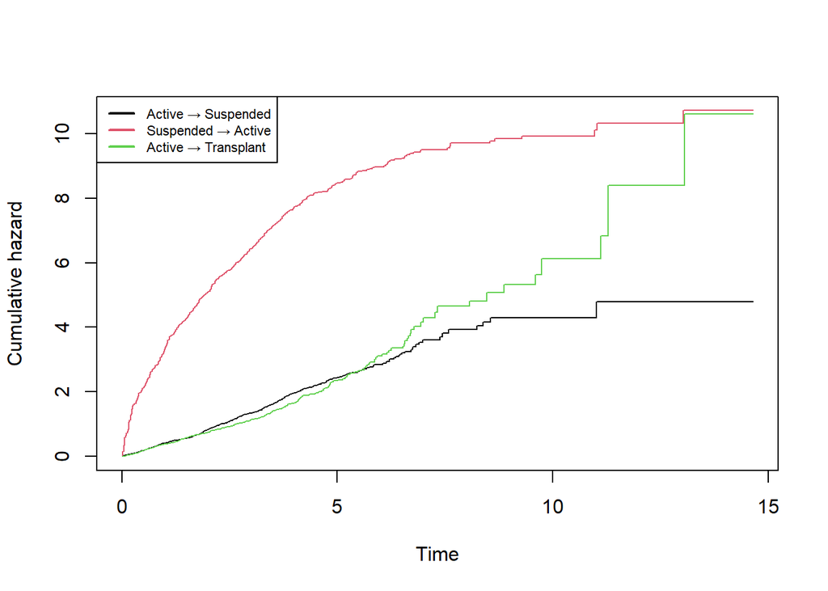

```r
#Newdata to predict on - ref levels
newdata_0 <- data.frame(
  trans=1:3,
  strata=1:3,
  hospunit.1 = factor(c(1,1,1)),
  hospunit.2=factor(c(1,1,1)),
  hospunit.3=factor(c(1,1,1)),
  age.1 = c(0,0,0),
  age.2 = c(0,0,0),
  age.3 = c(0,0,0),
  malesex.1=c(0,0,0),
  malesex.2=c(0,0,0),
  malesex.3 = c(0,0,0),
  late.1 = c(0,0,0),
  late.2 = c(0,0,0),
  late.3=c(4,4,4))

#Transition matrix
tmat <- matrix(c(
  NA, 1, 3,
  2, NA, NA,
  NA, NA, NA
), nrow = 3, byrow = TRUE)

class(tmat) <- "transMat"

#Cumulative hazards - ref levels
msfit_0 <- msfit(cox.strata, trans=tmat, newdata=newdata_0)

#Plot of cumulative hazards
#| fig-width: 2
#| fig-height: 3
plot(msfit_0, legend=FALSE)

legend(
  "topleft",
  legend = c("Active → Suspended", "Suspended → Active", "Active → Transplant"),
  col = 1:3,
  lty = 1,
  lwd = 2,
  cex=0.7
)
```

```r
#Probabilities in state
pr_0 <- probtrans(msfit_0, predt = 0, variance=FALSE)

#Check output for from entry to recur
pr_0_est <- pr_0[[1]]
pr_0_est[1:10, ]
```

```
          time   pstate1     pstate2     pstate3
1  0.000000000 1.0000000 0.000000000 0.000000000
2  0.002737851 0.9979429 0.002057051 0.000000000
3  0.005475702 0.9969146 0.003085389 0.000000000
4  0.008213552 0.9948561 0.005143880 0.000000000
5  0.010951403 0.9907325 0.009267525 0.000000000
6  0.013689254 0.9886712 0.011328832 0.000000000
7  0.016427105 0.9866090 0.013390977 0.000000000
8  0.019164956 0.9877652 0.012234789 0.000000000
9  0.021902806 0.9849909 0.013267284 0.001741849
10 0.024640657 0.9839576 0.014300506 0.001741849
```

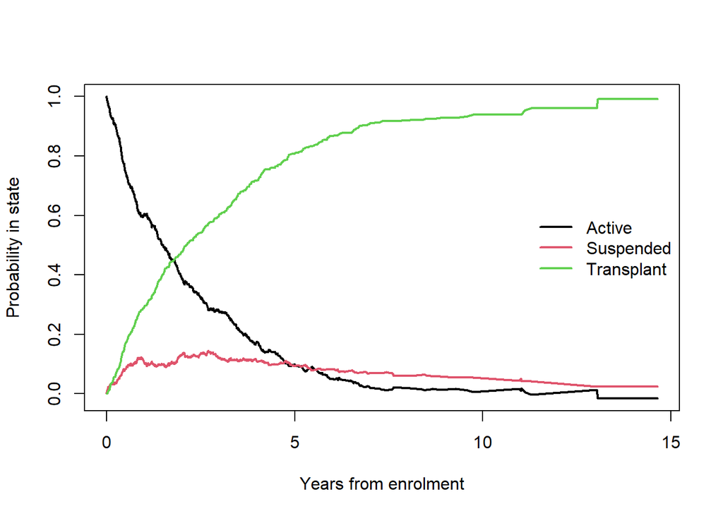

```r
#Plot of probabilities in state
#| fig-width: 2
#| fig-height: 3
matplot(pr_0_est$time,
        pr_0_est[, grep("^pstate", names(pr_0_est))],
        type = "l",
        lwd  = 2,
        lty  = 1,
        xlab = "Years from enrolment",
        ylab = "Probability in state")

# legend for states (colours)
legend("right",
       legend = c("Active", "Suspended", "Transplant"),
       col=1:3,
       lty    = 1,
       lwd    = 2,
       bty    = "n")
```

## Transition-specific flexible parametric survival model with 1 internal knot

We now fit the flexible parametric survival models for each transition, with 1 internal knot.

```r
#Fit separate models for each transition - as given by msprep
msm_active_sus <- flexsurvspline(Surv(Tstart, Tstop, status) ~ hospunit + age + malesex + late, data=wt_trans, subset=(trans==1), k=1, scale="hazard")
msm_active_sus
```

```
Call:
flexsurvspline(formula = Surv(Tstart, Tstop, status) ~ hospunit +
    age + malesex + late, data = wt_trans, subset = (trans ==
    1), k = 1, scale = "hazard")

Estimates:
           data mean  est        L95%       U95%       se         exp(est)
gamma0            NA  -1.443826  -1.954775  -0.932876   0.260693         NA
gamma1            NA   0.828062   0.627641   1.028484   0.102258         NA
gamma2            NA  -0.009348  -0.016682  -0.002014   0.003742         NA
hospunit2   0.180742  -0.512587  -0.717429  -0.307745   0.104513   0.598944
hospunit3   0.134175   0.090501  -0.129890   0.310891   0.112446   1.094722
age        47.123125   0.005231  -0.000365   0.010827   0.002855   1.005245
malesex     0.614049   0.093928  -0.053209   0.241065   0.075071   1.098481
late        0.149171   0.061139  -0.148176   0.270454   0.106795   1.063046
           L95%       U95%
gamma0            NA         NA
gamma1            NA         NA
gamma2            NA         NA
hospunit2   0.488005   0.735103
hospunit3   0.878192   1.364641
age         0.999635   1.010886
malesex     0.948182   1.272604
late        0.862279   1.310559

N = 1267,  Events: 749,  Censored: 518
Total time at risk: 1432.789
Log-likelihood = -1211.741, df = 8
AIC = 2439.481
```

```r
msm_sus_active <- flexsurvspline(Surv(Tstart, Tstop, status) ~ hospunit + age + malesex + late, data=wt_trans, subset=(trans==2), k=1, scale="hazard")
msm_sus_active
```

```
Call:
flexsurvspline(formula = Surv(Tstart, Tstop, status) ~ hospunit +
    age + malesex + late, data = wt_trans, subset = (trans ==
    2), k = 1, scale = "hazard")

Estimates:
           data mean  est       L95%      U95%      se        exp(est)
gamma0           NA    3.02145   2.21489   3.82801   0.41152        NA
gamma1           NA    0.01777  -0.00644   0.04198   0.01235        NA
gamma2           NA   -0.00523  -0.00804  -0.00242   0.00143        NA
hospunit2   0.17522   -0.43469  -0.73232  -0.13706   0.15185   0.64747
hospunit3   0.12165    0.59776   0.32831   0.86722   0.13748   1.81805
age        49.00558   -0.01967  -0.02591  -0.01342   0.00319   0.98053
malesex     0.59598   -0.17540  -0.36644   0.01564   0.09747   0.83912
late        0.14286   -0.00743  -0.26095   0.24609   0.12935   0.99260
           L95%      U95%
gamma0           NA        NA
gamma1           NA        NA
gamma2           NA        NA
hospunit2   0.48079   0.87192
hospunit3   1.38862   2.38028
age         0.97442   0.98667
malesex     0.69320   1.01576
late        0.77032   1.27902

N = 896,  Events: 446,  Censored: 450
Total time at risk: 1122.669
Log-likelihood = -728.9019, df = 8
AIC = 1473.804
```

```r
msm_active_tx <- flexsurvspline(Surv(Tstart, Tstop, status) ~ hospunit + age + malesex + late, data=wt_trans, subset=(trans==3), k=1, scale="hazard")
msm_active_tx
```

```
Call:
flexsurvspline(formula = Surv(Tstart, Tstop, status) ~ hospunit +
    age + malesex + late, data = wt_trans, subset = (trans ==
    3), k = 1, scale = "hazard")

Estimates:
           data mean  est       L95%      U95%      se        exp(est)
gamma0           NA   -1.15931  -1.65961  -0.65900   0.25526        NA
gamma1           NA    1.06925   0.82012   1.31839   0.12711        NA
gamma2           NA   -0.00600  -0.01901   0.00702   0.00664        NA
hospunit2   0.18074    0.14358  -0.09036   0.37751   0.11936   1.15440
hospunit3   0.13418    0.55107   0.27738   0.82476   0.13964   1.73511
age        47.12313   -0.01484  -0.02190  -0.00777   0.00360   0.98527
malesex     0.61405    0.30734   0.10650   0.50818   0.10247   1.35980
late        0.14917    0.01336  -0.26001   0.28674   0.13948   1.01345
           L95%      U95%
gamma0           NA        NA
gamma1           NA        NA
gamma2           NA        NA
hospunit2   0.91361   1.45865
hospunit3   1.31966   2.28134
age         0.97834   0.99226
malesex     1.11238   1.66226
late        0.77104   1.33207

N = 1267,  Events: 419,  Censored: 848
Total time at risk: 1432.789
Log-likelihood = -906.2689, df = 8
AIC = 1828.538
```

We bind these into one object and further produce the cumulative hazard and probability in state.

```r
#Define transition matrix
tmat2 <- rbind(c(NA,1,3), c(2,NA,NA), c(NA,NA,NA))
tmat2
```

```
     [,1] [,2] [,3]
[1,]   NA    1    3
[2,]    2   NA   NA
[3,]   NA   NA   NA
```

```r
#Group transitions together
flex_mods <- fmsm(msm_active_sus, msm_sus_active, msm_active_tx, trans=tmat2)
flex_mods
```

```
State 1 - State 2
flexsurvspline(formula = Surv(Tstart, Tstop, status) ~ hospunit +
    age + malesex + late, data = wt_trans, subset = (trans ==
    1), k = 1, scale = "hazard")

State 2 - State 1
flexsurvspline(formula = Surv(Tstart, Tstop, status) ~ hospunit +
    age + malesex + late, data = wt_trans, subset = (trans ==
    2), k = 1, scale = "hazard")

State 1 - State 3
flexsurvspline(formula = Surv(Tstart, Tstop, status) ~ hospunit +
    age + malesex + late, data = wt_trans, subset = (trans ==
    3), k = 1, scale = "hazard")
```

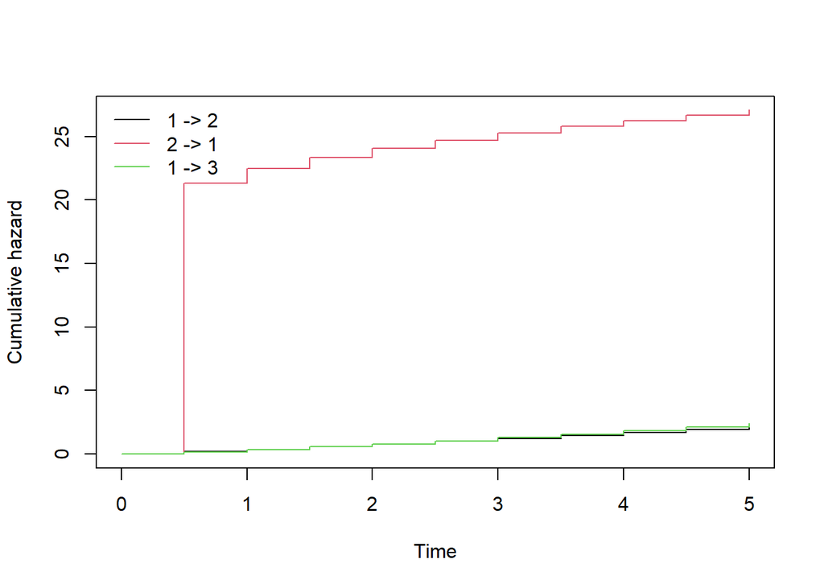

```r
#Newdata to predict on - control
newdata_f0 <- data.frame(
  hospunit = as.factor(c(1)),
  age=c(0),
  malesex=c(0),
  late=c(0))

#Cumulative transition specific hazard function - control
haz_flexs <- msfit.flexsurvreg(flex_mods, t=seq(0,5,by=0.5), newdata=newdata_f0, trans=tmat2)

#Plot
plot(haz_flexs)
```

```r
#Probability in state - control
prob_flexs <- probtrans(haz_flexs, predt=0, direction="forward")

#Store output
prob_flexs0 <- prob_flexs[[1]]
prob_flexs0
```

```
   time    pstate1    pstate2   pstate3        se1        se2        se3
1   0.0 1.00000000 0.00000000 0.0000000 0.00000000 0.00000000 0.00000000
2   0.5 0.66013180 0.18070582 0.1591624 1.86550834 1.86512237 0.02311238
3   1.0 0.61486854 0.09890610 0.2862254 0.97302212 0.61319809 0.36151818
4   1.5 0.44654518 0.13615605 0.4172988 0.10100000 0.13789733 0.16060885
5   2.0 0.34867373 0.13147376 0.5198525 0.14162577 0.08656999 0.15473273
6   2.5 0.27045290 0.12484259 0.6047045 0.12056323 0.08229268 0.13232832
7   3.0 0.21033389 0.11596694 0.6736992 0.10208049 0.07538974 0.11408293
8   3.5 0.16419796 0.10626948 0.7295326 0.08612205 0.06790038 0.09906096
9   4.0 0.12887851 0.09648057 0.7746409 0.07260844 0.06069953 0.08657498
10  4.5 0.10181567 0.08705348 0.8111308 0.06127119 0.05411406 0.07609339
11  5.0 0.08101089 0.07824488 0.8407442 0.05180306 0.04823963 0.06721121
```

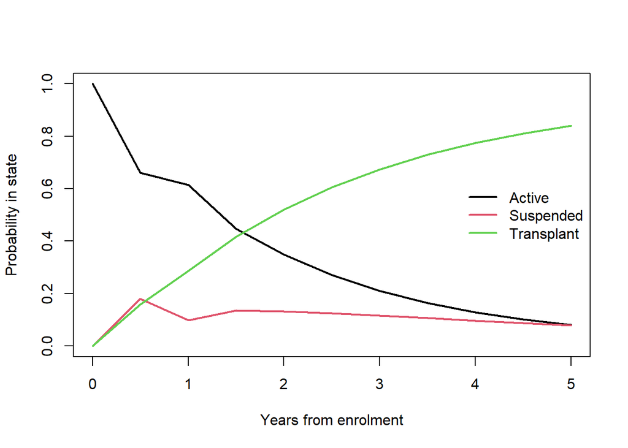

```r
#Plot of probabilities in state
#| fig-width: 2
#| fig-height: 3
matplot(prob_flexs0$time,
        prob_flexs0[, grep("^pstate", names(prob_flexs0))],
        type = "l",
        lwd  = 2,
        lty  = 1,
        xlab = "Years from enrolment",
        ylab = "Probability in state")

# legend for states (colours)
legend("right",
       legend = c("Active", "Suspended", "Transplant"),
       col=1:3,
       lty    = 1,
       lwd    = 2,
       bty    = "n")
```

We can also quite easily derive the expected time in each state.

```r
#Expected time in states by 5 years
ELOS(prob_flexs, t=5)
```

```
           in1        in2      in3
from1 1.972949  0.5389274 2.488124
from2 4.456584 -7.4831773 8.026593
from3 0.000000  0.0000000 5.000000
```

**Important**

We have several important things to mention in this analysis

- PH assumption is violated in Cox models  
  ➡️ should consider alternate model or addressing PH through other means (e.g. time-varying coefficient)
- Regardless, both Cox and flexible parametric survival model have difficulty fitting this multi-state model, which we observed when producing the probability in state  
  ➡️ this is not driven by PH assumption
- What can we do about it? Further exploration of whether we can better fit the model  
  ➡️ Add time-varying covariate for past transitions to suspensions  
  ➡️ Consider suspensions must be for a minimum time of *x* months to be considered in model (reduce small frequent suspensions)  
  ➡️ Consider alternative better fitting models, such as more knots in flexible parametric, or fully parametric model